# KNN

#K Nearest Neighbors

## Análisis del Problema

###Introduction El problema es pronosticar el tipo de clase sobre la base del análisis químico. El estudio de la clasificación de los tipos de vidrio fue motivado por la investigación criminológica. En la escena del crimen, el vidrio que queda puede usarse como evidencia (¡si se identifica correctamente!).

**Algoritmo:**

- Calcule la distancia desde x hasta todos los puntos en sus datos.
- Ordene los puntos en sus datos aumentando la distancia desde x.
- Predecir la etiqueta mayoritaria de los puntos más cercanos `k`.

Tenga en cuenta que el valor de `k` afecta los resultados, es ideal para probar el modelo para diferentes valores de`k` para obtener mejores resultados y por un mejor modelo

## Entendimiento de los Datos

** La base de datos de identificación de vidrio ** de UCI contiene 10 atributos que incluyen `id`. La respuesta es “tipo de vidrio” que tiene 7 valores discretos. https://archive.ics.uci.edu/ml/datasets/Glass+Identification [UCI Database](https://archive.ics.uci.edu/ml/machine-learning-databases/glass/glass.data) `Dataset`.

###Environment setup

Permite instalar y cargar las bibliotecas requeridas.

```r
#install.packages('caTools')  #for train and test data split
#install.packages('dplyr')    #for Data Manipulation
#install.packages('ggplot2')  #for Data Visualization
#install.packages('class')    #KNN
#install.packages('caret')    #Confusion Matrix
#install.packages('corrplot') #Correlation Plot
```

```r
library(caTools)
library(dplyr)
```

```r
library(ggplot2)
library(caret)
library(class)
library(corrplot)
library(readr)
glass <- read.csv("datos/glass.data",col.names=c("Id", "RI", "Na", "Mg", "Al", "Si", "K", "Ca", "Ba", "Fe", "Type"))
```

###Standardize the Data

Es ideal para estandarizar las características de los datos, especialmente con el algoritmo KNN. Vamos a seguir adelante y estandarizar. Aquí estamos usando `scale ()` para estandarizar las columnas de características de `glass` y asignarlas a una nueva variable. Excluya la columna de destino `Tipo` mientras escala.

```r
standard.features <- scale(glass[,1:9])

#Une los datos estandarizados con la columna de destino
data <- cbind(standard.features,glass[10])
#Verifique si faltan valores para imputar.
anyNA(data)
```

```
## [1] FALSE
```

```r
# Parece que los datos están libres de NA
head(data)
```

```
##          Id         RI         Na        Mg         Al          Si
## 1 -1.719887 -0.2445246  0.5904893 0.6414256 -0.1730924  0.09686241
## 2 -1.703661 -0.7151409  0.1505911 0.6067143  0.1869924  0.43275722
## 3 -1.687436 -0.2280695 -0.2404295 0.7039059 -0.3131254 -0.05816597
## 4 -1.671211 -0.3070540 -0.1671131 0.6553101 -0.4131490  0.54902851
## 5 -1.654985 -0.7875434 -0.7536440 0.6483678  0.3470301  0.40691916
## 6 -1.638760 -0.3037630 -0.1304549 0.6414256 -0.6131961  0.56194754
##             K         Ca         Ba   Fe
## 1 -0.02926025 -0.7907366 -0.3529761 0.00
## 2 -0.16707818 -0.8257890 -0.3529761 0.00
## 3  0.10855768 -0.5173277 -0.3529761 0.00
## 4  0.07793148 -0.6224850 -0.3529761 0.00
## 5  0.21574941 -0.6224850 -0.3529761 0.26
## 6  0.12387079 -0.5523801 -0.3529761 0.00
```

```r
data$Type<- as.factor(glass$Type)
```

###Visualización de datos La siguiente gráfica explica la relación entre las diferentes características en el conjunto de datos `glass`.

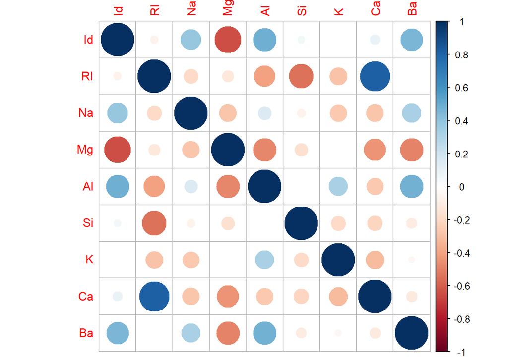

```r
corrplot(cor(data[,c(1,2,3,4,5,6,7,8,9)]))
```

### División de datos de prueba y entrenamiento

Utilizamos `caTools ()` para dividir los conjuntos de datos `data` en`train` y `test` con un`SplitRatio` = 0.70.

```r
set.seed(123)

splt <- sample.split(data$Type,SplitRatio = 0.7)

train <- data[splt,]

test <- data[!splt,]
```

###KNN Model

Usamos `knn ()` para predecir nuestra variable objetivo `Tipo` del conjunto de datos de prueba con`k = 1`.

```r
predicted.type <- knn(train[1:9],test[1:9],train$Type,k=1)
#Error in prediction
error <- mean(predicted.type!=test$Type)
#Confusion Matrix
confusionMatrix(predicted.type,test$Type)
```

```
## Confusion Matrix and Statistics
##
##           Reference
## Prediction  1  2  3  5  6  7
##          1 20  3  0  0  0  0
##          2  1 18  1  0  1  0
##          3  0  2  4  0  0  0
##          5  0  0  0  4  0  0
##          6  0  0  0  0  2  0
##          7  0  0  0  0  0  9
##
## Overall Statistics
##
##                Accuracy : 0.8769
##                  95% CI : (0.7718, 0.9453)
##     No Information Rate : 0.3538
##     P-Value [Acc > NIR] : < 2.2e-16
##
##                   Kappa : 0.8337
##
##  Mcnemar's Test P-Value : NA
##
## Statistics by Class:
##
##                      Class: 1 Class: 2 Class: 3 Class: 5 Class: 6 Class: 7
## Sensitivity            0.9524   0.7826  0.80000  1.00000  0.66667   1.0000
## Specificity            0.9318   0.9286  0.96667  1.00000  1.00000   1.0000
## Pos Pred Value         0.8696   0.8571  0.66667  1.00000  1.00000   1.0000
## Neg Pred Value         0.9762   0.8864  0.98305  1.00000  0.98413   1.0000
## Prevalence             0.3231   0.3538  0.07692  0.06154  0.04615   0.1385
## Detection Rate         0.3077   0.2769  0.06154  0.06154  0.03077   0.1385
## Detection Prevalence   0.3538   0.3231  0.09231  0.06154  0.03077   0.1385
## Balanced Accuracy      0.9421   0.8556  0.88333  1.00000  0.83333   1.0000
```

```r
predicted.type <- NULL
error.rate <- NULL

for (i in 1:10) {
  predicted.type <- knn(train[1:9],test[1:9],train$Type,k=i)
  error.rate[i] <- mean(predicted.type!=test$Type)

}

knn.error <- as.data.frame(cbind(k=1:10,error.type =error.rate))
```

###Elección del valor K por visualización

Vamos a trazar `error.type` vs`k` usando `ggplot`.

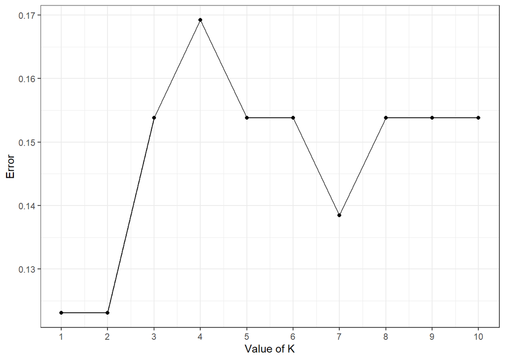

```r
    ggplot(knn.error,aes(k,error.type))+
      geom_point()+
      geom_line() +
      scale_x_continuous(breaks=1:10)+
      theme_bw() +
      xlab("Value of K") +
      ylab('Error')
```

###Result

```r
predicted.type <- knn(train[1:9],test[1:9],train$Type,k=3)
#Error in prediction
error <- mean(predicted.type!=test$Type)
#Confusion Matrix
confusionMatrix(predicted.type,test$Type)
```

```
## Confusion Matrix and Statistics
##
##           Reference
## Prediction  1  2  3  5  6  7
##          1 21  2  2  0  0  0
##          2  0 19  3  1  1  0
##          3  0  2  0  0  0  0
##          5  0  0  0  3  0  0
##          6  0  0  0  0  2  0
##          7  0  0  0  0  0  9
##
## Overall Statistics
##
##                Accuracy : 0.8308
##                  95% CI : (0.7173, 0.9124)
##     No Information Rate : 0.3538
##     P-Value [Acc > NIR] : 3.558e-15
##
##                   Kappa : 0.7647
##
##  Mcnemar's Test P-Value : NA
##
## Statistics by Class:
##
##                      Class: 1 Class: 2 Class: 3 Class: 5 Class: 6 Class: 7
## Sensitivity            1.0000   0.8261  0.00000  0.75000  0.66667   1.0000
## Specificity            0.9091   0.8810  0.96667  1.00000  1.00000   1.0000
## Pos Pred Value         0.8400   0.7917  0.00000  1.00000  1.00000   1.0000
## Neg Pred Value         1.0000   0.9024  0.92063  0.98387  0.98413   1.0000
## Prevalence             0.3231   0.3538  0.07692  0.06154  0.04615   0.1385
## Detection Rate         0.3231   0.2923  0.00000  0.04615  0.03077   0.1385
## Detection Prevalence   0.3846   0.3692  0.03077  0.04615  0.03077   0.1385
## Balanced Accuracy      0.9545   0.8535  0.48333  0.87500  0.83333   1.0000
```

El modelo anterior nos dio una precisión de **83.0769231 %.**